# Module 11

Riley Nelson

2022-11-28

## Overview

North Carolina is home to one of the largest swine production industries in the country, and ranks third among states in number of hogs produced after Iowa and Minnesota. Unlike Iowa and Minnesota, North Carolina is vulnerable to extensive hurricane-driven flooding. Most swine in North Carolina are produced in the eastern part of the state, which is also the region that receives the brunt of hurricane-driven flooding. As a result, hog farms are vulnerable to flooding. Floods can lead to mass death of pigs on a farm, and can also result in pollutant sources, such as manure, flowing into waterways. In this assignment, you will identify which swine farms in the Neuse River Watershed are most susceptible to flooding.

## Part One

Code used to determine the amount of swine farms in North Carolina. In this code, the data was read in and then sorted. The code was then used to create the graphic.

```r
swine_farms <- read_sf("spatial_data/swine_farms.shp")

river_basins <- read_sf("spatial_data/river_basins_SIMPLE.shp")

swine <- st_transform(swine_farms, crs = 32119)
river <- st_transform(river_basins, crs = 32119)

st_crs(river_basins)
```

```
## Coordinate Reference System:
##   User input: Lambert_Conformal_Conic
##   wkt:
## PROJCRS["Lambert_Conformal_Conic",
##     BASEGEOGCRS["GCS_GRS 1980(IUGG, 1980)",
##         DATUM["D_unknown",
##             ELLIPSOID["GRS80",6378137,298.257222101,
##                 LENGTHUNIT["metre",1,
##                     ID["EPSG",9001]]]],
##         PRIMEM["Greenwich",0,
##             ANGLEUNIT["Degree",0.0174532925199433]]],
##     CONVERSION["unnamed",
##         METHOD["Lambert Conic Conformal (2SP)",
##             ID["EPSG",9802]],
##         PARAMETER["Latitude of false origin",33.75,
##             ANGLEUNIT["Degree",0.0174532925199433],
##             ID["EPSG",8821]],
##         PARAMETER["Longitude of false origin",-79,
##             ANGLEUNIT["Degree",0.0174532925199433],
##             ID["EPSG",8822]],
##         PARAMETER["Latitude of 1st standard parallel",36.1666666666667,
##             ANGLEUNIT["Degree",0.0174532925199433],
##             ID["EPSG",8823]],
##         PARAMETER["Latitude of 2nd standard parallel",34.3333333333333,
##             ANGLEUNIT["Degree",0.0174532925199433],
##             ID["EPSG",8824]],
##         PARAMETER["Easting at false origin",609601.22,
##             LENGTHUNIT["metre",1],
##             ID["EPSG",8826]],
##         PARAMETER["Northing at false origin",0,
##             LENGTHUNIT["metre",1],
##             ID["EPSG",8827]]],
##     CS[Cartesian,2],
##         AXIS["(E)",east,
##             ORDER[1],
##             LENGTHUNIT["metre",1,
##                 ID["EPSG",9001]]],
##         AXIS["(N)",north,
##             ORDER[2],
##             LENGTHUNIT["metre",1,
##                 ID["EPSG",9001]]]]
```

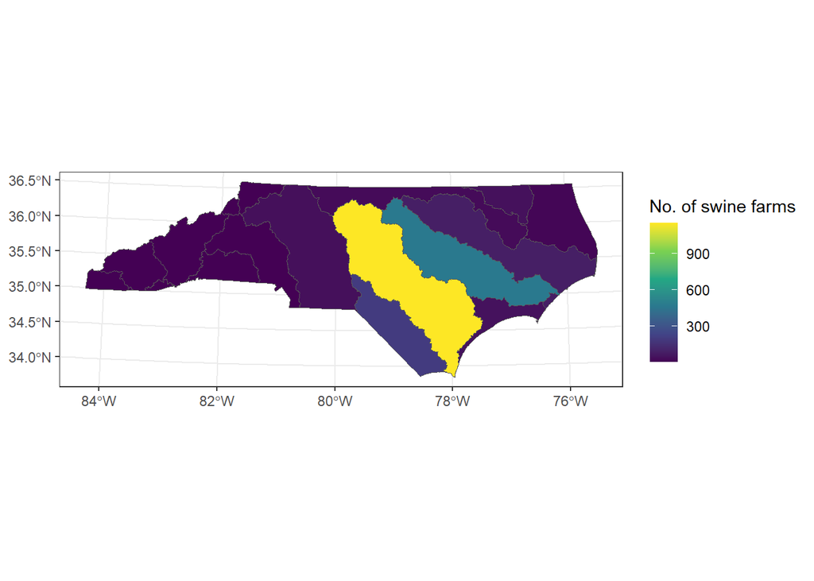

```r
river_swine <- st_join(river, swine)

river_swine %>%
  group_by(Name) %>%
  count() -> basins

ggplot() +
  geom_sf(data = basins, aes(fill = n)) +
  scale_fill_viridis_c(name = "No. of swine farms") +
  theme_bw()
```

## Part Two

In part two, the data is focused on the Neuse basin. During this section, the data is read in and then sorted. From there the data is then used to create the graphic seen below.

```r
neuse <- read_sf("spatial_data/neuse_waterways.shp")

neuse <- st_transform(neuse, crs = 32119)

river_basins %>%
  filter(Basin == "NEU") -> neuse_base


neuse_buff <- st_buffer(neuse, dist = (1*10^3))

neuse_int <- st_intersection(swine, neuse_buff)
```

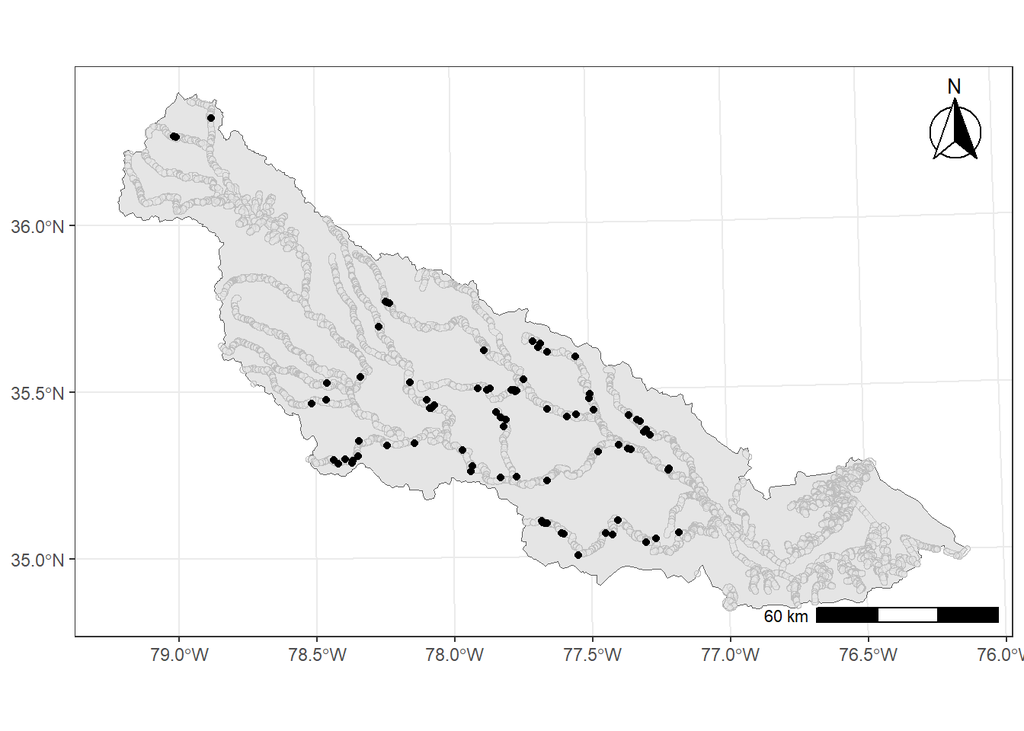

```r
ggplot() +
  geom_sf(data = neuse_base) +
  geom_sf(data = neuse_buff, col = "gray", alpha = 0.5) +
  geom_sf(data = neuse_int) +
  theme_bw() +
  annotation_scale(location = "br") +
  annotation_north_arrow(location = "tr", style = north_arrow_fancy_orienteering)
```